# Exploratory Data Analysis

Saira Kaleem

January 08, 2021

##### NOTE:

1. Change author name and date to your exercise submission date in above section
2. Your code MUST execute without errors.
3. You can add more lines in your code as required.

## Section 1: Summary Statistics

### Question 1

**The dataset is loaded for you. Perform the following tasks:**

1. Using the airquality dataset, generate the five-point summary through the appropriate function.
2. Visualize the data for temperature through histogram. Add color and labels.
3. Visualize the distribution of data for Wind. Add colors and labels.
4. Visualize the relationship between Solar.R and Ozone. Use scatterplot and circular red markers to identify the points.

```r
library(datasets)
head(airquality)
```

```
##   Ozone Solar.R Wind Temp Month Day
## 1    41     190  7.4   67     5   1
## 2    36     118  8.0   72     5   2
## 3    12     149 12.6   74     5   3
## 4    18     313 11.5   62     5   4
## 5    NA      NA 14.3   56     5   5
## 6    28      NA 14.9   66     5   6
```

```r
##Generating Five point summary
summary(airquality)
```

```
##      Ozone           Solar.R           Wind             Temp
##  Min.   :  1.00   Min.   :  7.0   Min.   : 1.700   Min.   :56.00
##  1st Qu.: 18.00   1st Qu.:115.8   1st Qu.: 7.400   1st Qu.:72.00
##  Median : 31.50   Median :205.0   Median : 9.700   Median :79.00
##  Mean   : 42.13   Mean   :185.9   Mean   : 9.958   Mean   :77.88
##  3rd Qu.: 63.25   3rd Qu.:258.8   3rd Qu.:11.500   3rd Qu.:85.00
##  Max.   :168.00   Max.   :334.0   Max.   :20.700   Max.   :97.00
##  NA's   :37       NA's   :7
##      Month            Day
##  Min.   :5.000   Min.   : 1.0
##  1st Qu.:6.000   1st Qu.: 8.0
##  Median :7.000   Median :16.0
##  Mean   :6.993   Mean   :15.8
##  3rd Qu.:8.000   3rd Qu.:23.0
##  Max.   :9.000   Max.   :31.0
##
```

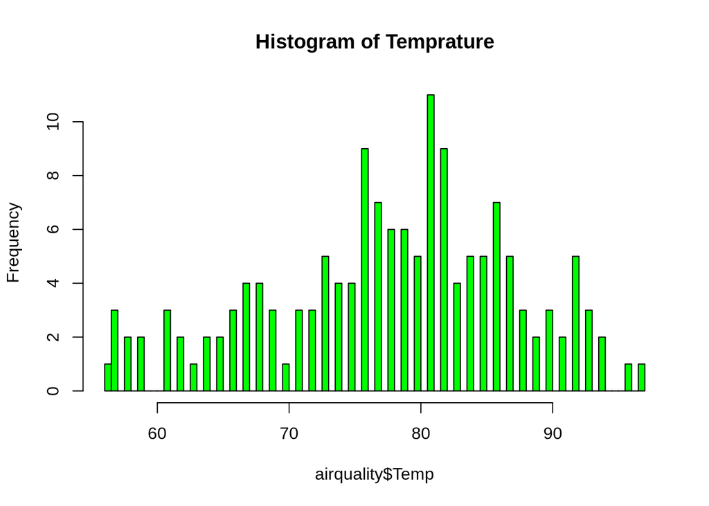

```r
##Histogram of temprature/Adding labels and color
hist(airquality$Temp, col="green",main = "Histogram of Temprature",breaks = 100)
```

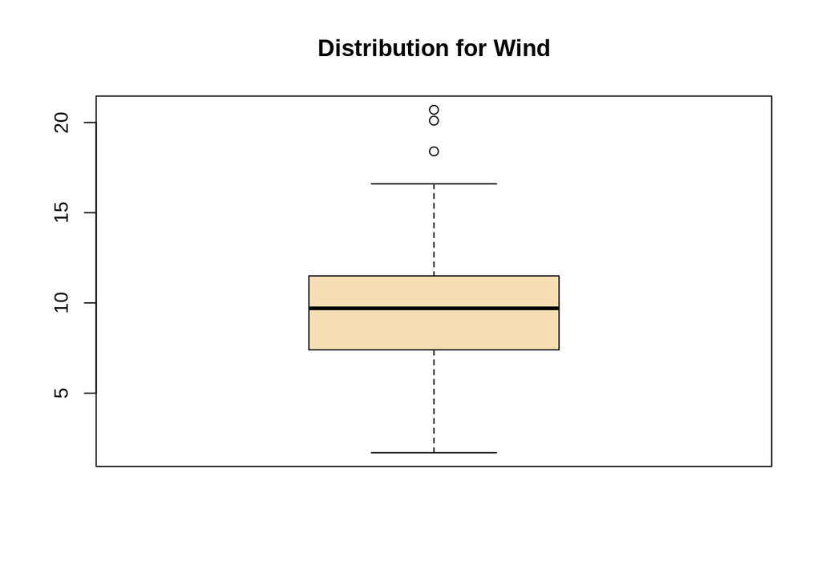

```r
##Distribution of data for Wind
boxplot(airquality$Wind,col = "wheat", main = "Distribution for Wind")
```

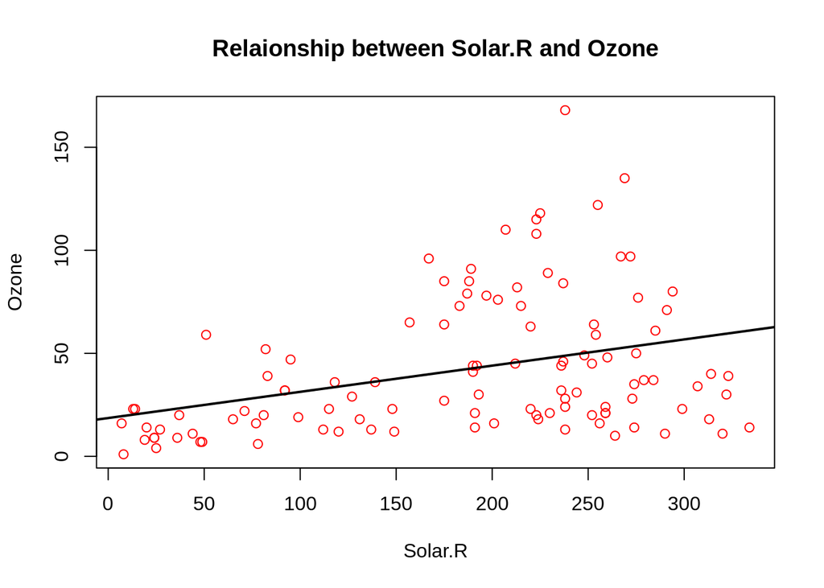

```r
##Relaionship between Solar.R and Ozone
with(airquality, plot(Solar.R, Ozone, main="Relaionship between Solar.R and Ozone",col="red"))
model <- lm(Ozone ~ Solar.R, airquality)
abline(model, lwd = 2)
```

### Good Job! You have completed this section!

## Section 2: Plotting Systems in R: Base, lattice, ggplot2

### Question 1

**The dataset is loaded for you. Perform the following tasks:**

1. Using the state.x77 and state.region datasets, visualize the relationship between Income and illiteracy.
2. Visualize the relationship between Population, region and life expectancy (Life.Exp)
3. Export the charts to a pdf file.

You can use either lattice or ggplot2 libraries to accomplish this task.

```r
library(lattice)
library(ggplot2)

head(state.x77)
```

```
##            Population Income Illiteracy Life Exp Murder HS Grad Frost   Area
## Alabama          3615   3624        2.1    69.05   15.1    41.3    20  50708
## Alaska            365   6315        1.5    69.31   11.3    66.7   152 566432
## Arizona          2212   4530        1.8    70.55    7.8    58.1    15 113417
## Arkansas         2110   3378        1.9    70.66   10.1    39.9    65  51945
## California      21198   5114        1.1    71.71   10.3    62.6    20 156361
## Colorado         2541   4884        0.7    72.06    6.8    63.9   166 103766
```

```r
head(state.region)
```

```
## [1] South West  West  South West  West
## Levels: Northeast South North Central West
```

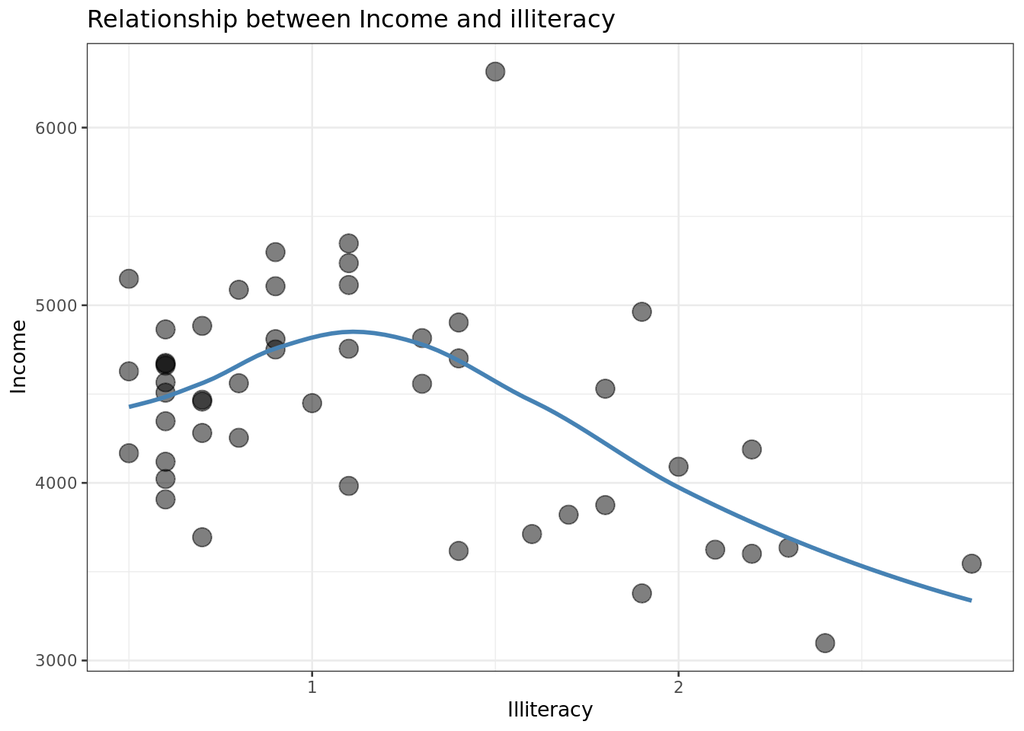

```r
state.x77<-as.data.frame(state.x77)
state.x77$state_region<-state.region
state.x77$'Life Exp'->state.x77$Life_Exp
##Relationship between Income nad Illiteracy
Income_Illiteracy <- ggplot(state.x77, aes(Illiteracy,Income)) +
                     geom_point(alpha=1/2,size=4) +
                     geom_smooth(se=FALSE, col="steelblue") +
                     theme_bw(base_family = "Avenir", base_size = 10) +
                     labs(title = "Relationship between Income and illiteracy")
print(Income_Illiteracy)
```

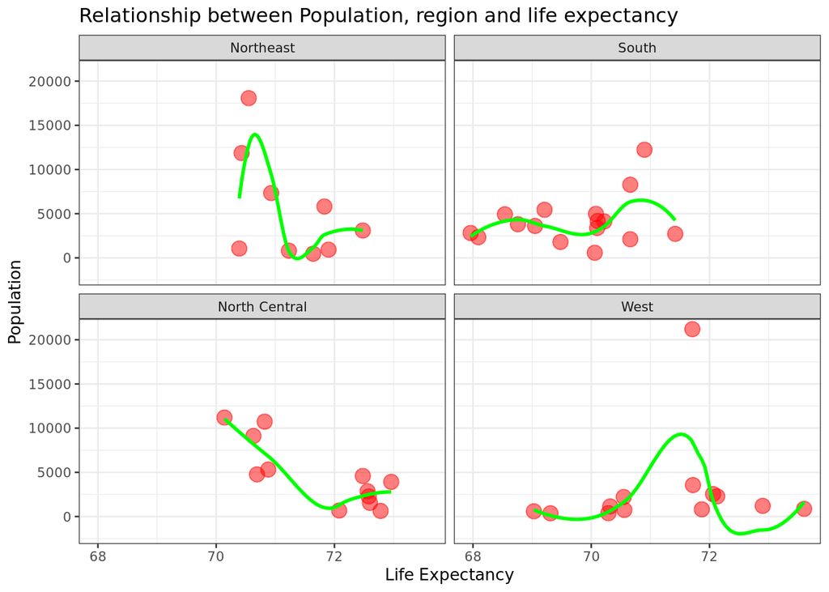

```r
##Visualize the relationship between Population, region and life expectancy (Life.Exp)
Population_life <- ggplot(state.x77, aes(Life_Exp,Population)) + geom_point(alpha=1/2,size=4,color="red") +                                                 geom_smooth(se=FALSE,col="green")+
                   facet_wrap(facets = vars(state_region)) + theme_bw(base_family = "Avenir", base_size = 10) +
                   labs(x = "Life Expectancy") +
                   labs(y = "Population") +
                   labs(title = "Relationship between Population, region and life expectancy")
print(Population_life)
```

### Question 2

**The dataset is loaded for you. Perform the following tasks:**

1. Using the visualize the relationship between height and weight from the women dataset.
2. Is there a strong correlation between the two quantities? Compute correlation coefficient and fit a linear regression model
3. Export the charts and results to a pdf file.

```r
head(women)
```

```
##   height weight
## 1     58    115
## 2     59    117
## 3     60    120
## 4     61    123
## 5     62    126
## 6     63    129
```

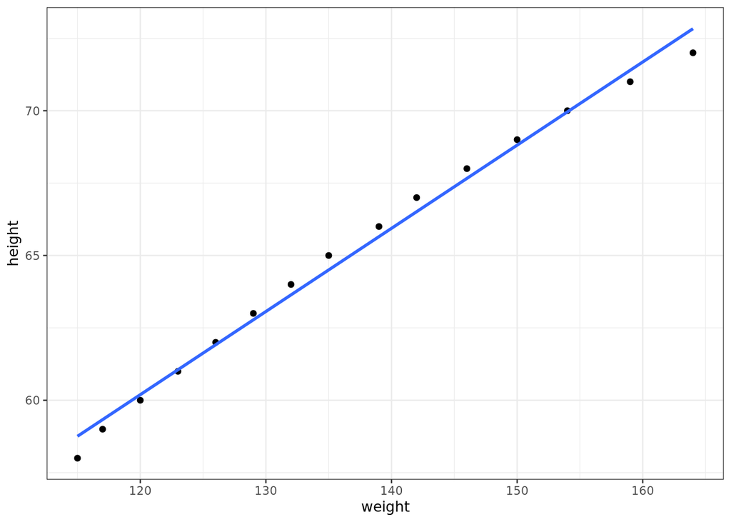

```r
g <- ggplot(women, aes(weight,height))
g + geom_point() + geom_smooth(method = lm, se=FALSE) + theme_bw(base_family = "Avenir", base_size = 10)
```

```r
##Exporting the charts and results to a pdf file.
pdf("g.pdf")
g <- ggplot(women, aes(weight,height))
g + geom_point() + geom_smooth(method = lm)
```

### Good Job! You have completed this section!

## Section 3: Aesthetics and Visuals of ggplot2

### Question 1

**The dataset is loaded for you. Perform the following tasks:**

1. Using the longley dataset, plot the relationship between Umployed and GNP.
2. As a scatter plot, plot out Unemployed values as blue dots and Employed values as green dots.
3. Create a new variable as a column known as Armed.Forces.Unemployed.Rel. In it, place a Y for when the number of armed forces are greater than unemployed and N otherwise. Plot a graph to show the relationship between unemployed and armed forces and use the Armed.Forces.Unemployed.Rel for aesthetics and color.

Add appropriate title, axis labels and charts for EACH of the above charts. You need to use ggplot2 to accomplish this task.

```r
head(longley)
```

```
##      GNP.deflator     GNP Unemployed Armed.Forces Population Year Employed
## 1947         83.0 234.289      235.6        159.0    107.608 1947   60.323
## 1948         88.5 259.426      232.5        145.6    108.632 1948   61.122
## 1949         88.2 258.054      368.2        161.6    109.773 1949   60.171
## 1950         89.5 284.599      335.1        165.0    110.929 1950   61.187
## 1951         96.2 328.975      209.9        309.9    112.075 1951   63.221
## 1952         98.1 346.999      193.2        359.4    113.270 1952   63.639
```

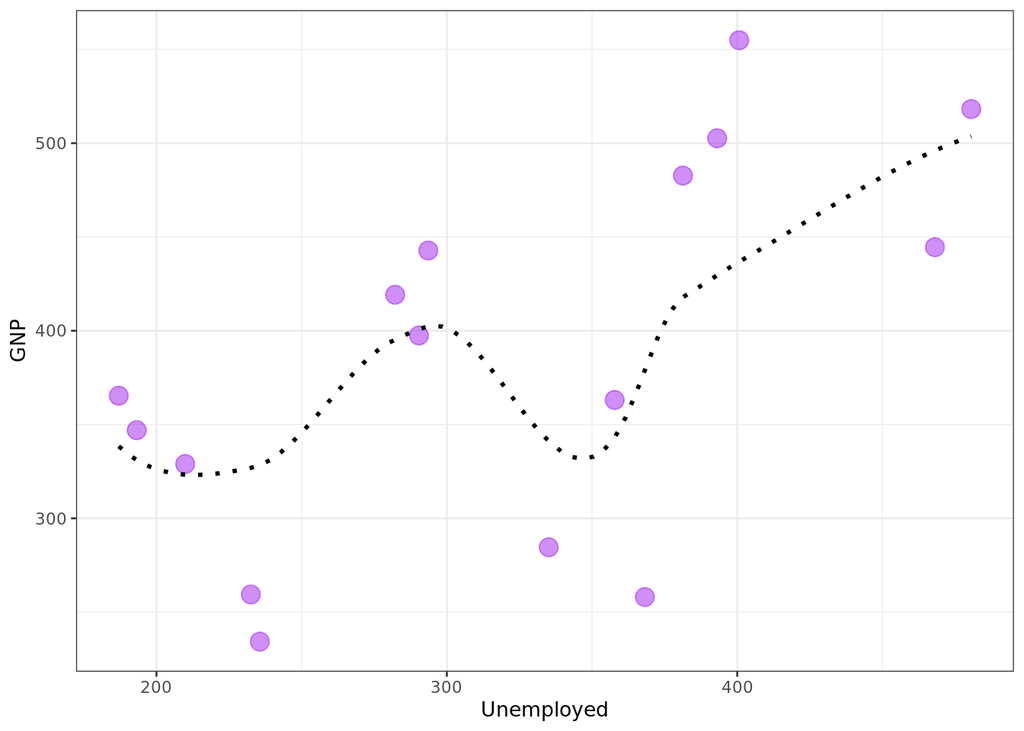

```r
##Using the longley dataset, plot the relationship between Umployed and GNP
g <- ggplot(longley, aes(Unemployed,GNP)) +
     geom_point(alpha=1/2,color="purple",size=4) +
     geom_smooth(se=FALSE,color="black",size=1,lty=15) +
     theme_bw(base_family = "Avenir", base_size = 10)

print(g)
```

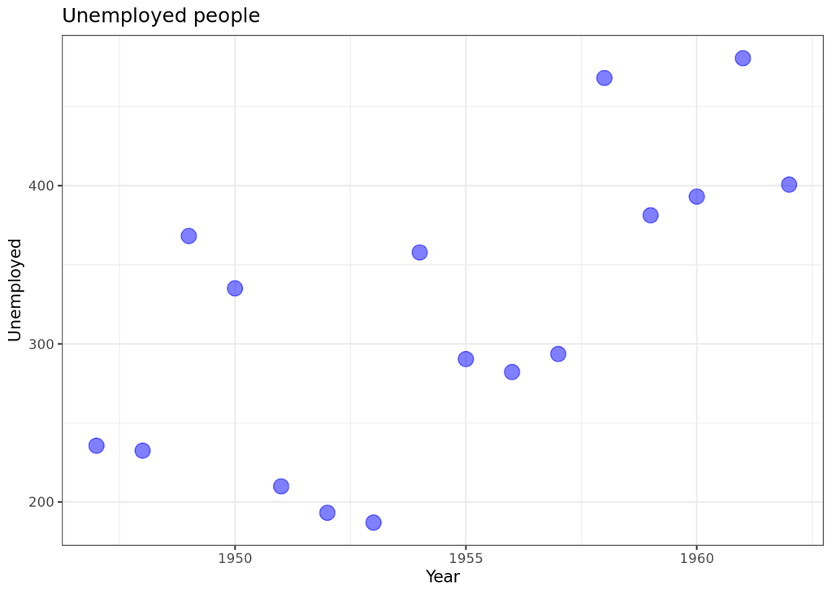

```r
##As a scatter plot, plot out Unemployed values as blue dots and Employed values as green dots
g <- ggplot(longley, aes(Year,Unemployed)) +
     geom_point(alpha=1/2,color="blue",size=4)+
     theme_bw(base_family = "Avenir", base_size = 10)+
     labs(title="Unemployed people")

print(g)
```

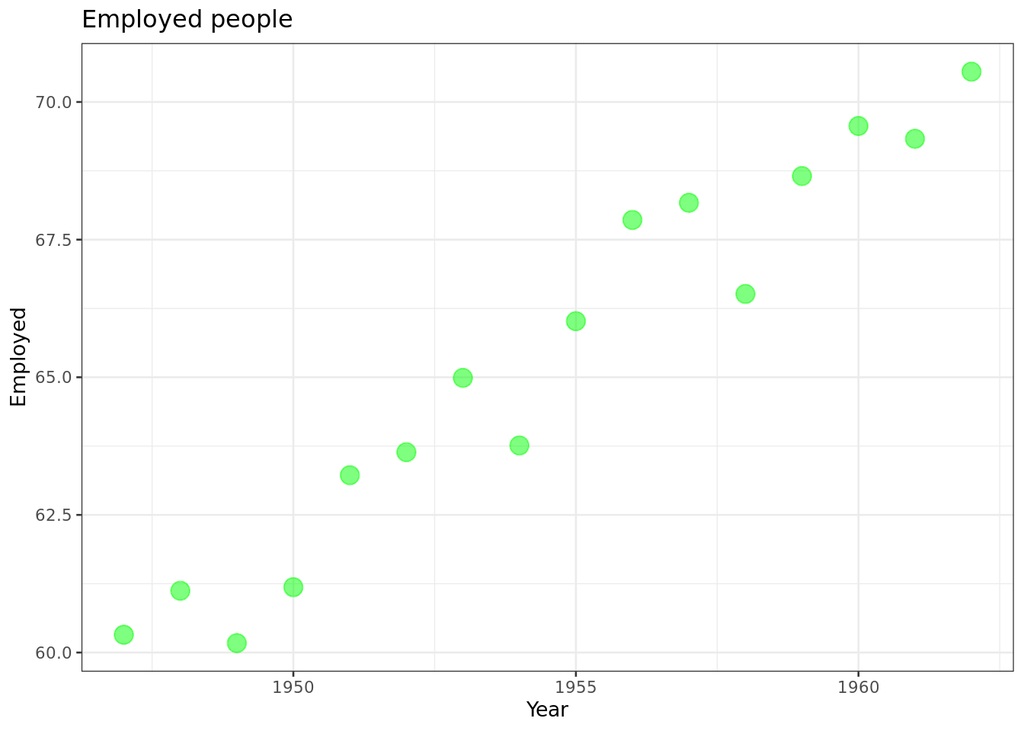

```r
g <- ggplot(longley, aes(Year,Employed)) +
     geom_point(alpha=1/2,color="green",size=4) +
     theme_bw(base_family = "Avenir", base_size = 10) +
     labs(title="Employed people")
print(g)
```

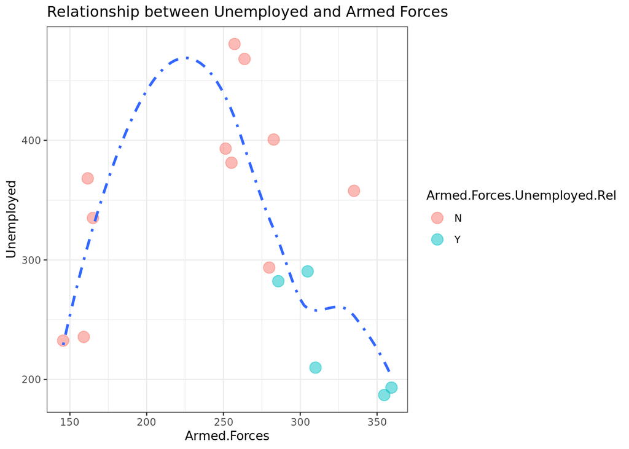

```r
longley <- as.data.frame(longley)
## 3.
Armed.Forces.Unemployed.Rel <- c("N","N","N","N","Y","Y","Y","N","Y","Y","N","N","N","N","N","N")
longley$Armed.Forces.Unemployed.Rel <- Armed.Forces.Unemployed.Rel


g <- ggplot(longley, aes(Armed.Forces,Unemployed)) +
     geom_point(alpha=1/2,aes(color = Armed.Forces.Unemployed.Rel),size=4)+
     geom_smooth(se=FALSE,lty=10) +
     theme_bw(base_family = "Avenir", base_size = 10)+
     labs(title="Relationship between Unemployed and Armed Forces")
print(g)
```

### Congratulations! You have successfully completed this course and practice exercises!